# Walmart Store Sales Forcasting

Farid Saud

Notes on the making of this code/R markdown file, and total run-time are presented at the end of this document. To download the data and the source code, click here.

## Overview

This project explores historical sales data from 45 Walmart stores spread across different regions, and explores different approaches to predict the future weekly sales for every department in each store. The data was obtained from https://www.kaggle.com/c/walmart-recruiting-store-sales-forecasting.

### Set-up

```r
knitr::opts_chunk$set(echo = TRUE,fig.align='center')
start.time <- Sys.time()
```

### **Libraries**

The following are the libraries used in the script and its purpose: - `tidyverse`: Data processing, data wrangling, and plots. - `lubridate`: Framework to handle dates and times. - `viridis`: Color palette.

```r
knitr::opts_chunk$set(echo = TRUE, fig.align='center')

library(knitr)
#library(class)

# Progress bar
library(progress)

# Misc.
library(tidyverse) ## Includes ggplot and caret
library(lubridate)

#For the plots:
library(viridis) #color palette
library(UpSetR)
```

## **Part I: Training Data**

### 1.1. Loading the training data:

The training data for this project is stored in 10 separate “folds”. There is a train.csv file in every fold, each containing 5 columns:

- `Store`
- `Dept`
- `Date`
- `Weekly_Sales`
- `IsHoliday`

```r
for (fold in 1:10) {

  # Construct the path to the files for this fold
  fold_folder <- file.path("./Proj2_Data", paste0("fold_", fold))

  # Read the training data
  train_path <- file.path(fold_folder, "train.csv")
  assign(paste0("train_", fold), read.csv(train_path, header = TRUE))

}
```

These datasets look like the following:

```r
head(train_7)
```

```
##   Store Dept       Date Weekly_Sales IsHoliday
## 1     1    1 2010-02-05     24924.50     FALSE
## 2     1    1 2010-02-12     46039.49      TRUE
## 3     1    1 2010-02-19     41595.55     FALSE
## 4     1    1 2010-02-26     19403.54     FALSE
## 5     1    1 2010-03-05     21827.90     FALSE
## 6     1    1 2010-03-12     21043.39     FALSE
```

### 1.2. NA observations:

```r
for (fold in 1:10) {

  # Construct the path to the files for this fold
  train <- get(paste0("train_", fold))

  # Read the training data
  tmp <- as.matrix(t(table(complete.cases(train))))

  cat("Complete.cases for ", paste0("fold_", fold), ": ", tmp, " \n                    , out of ", dim(train)[1],"\n\n")
}
```

```
## Complete.cases for  fold_1 :  164115
##                     , out of  164115
##
## Complete.cases for  fold_2 :  190674
##                     , out of  190674
##
## Complete.cases for  fold_3 :  214217
##                     , out of  214217
##
## Complete.cases for  fold_4 :  240603
##                     , out of  240603
##
## Complete.cases for  fold_5 :  267184
##                     , out of  267184
##
## Complete.cases for  fold_6 :  294132
##                     , out of  294132
##
## Complete.cases for  fold_7 :  317928
##                     , out of  317928
##
## Complete.cases for  fold_8 :  344667
##                     , out of  344667
##
## Complete.cases for  fold_9 :  371242
##                     , out of  371242
##
## Complete.cases for  fold_10 :  397841
##                     , out of  397841
```

### 1.3. Investigation of observations of training datasets: Folds, stores, and departments in stores:

This section explores more in depth how many `Weekly_Sales` observations there are in the training datasets, per store and department. For this purpose, the initial step taken is to analyse the count of observations per store and department in the training datasets:

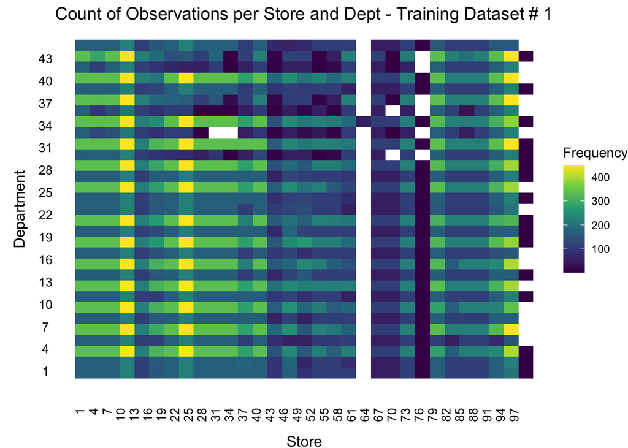

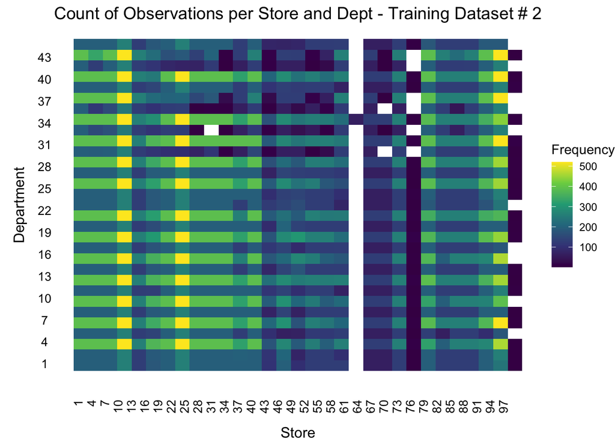

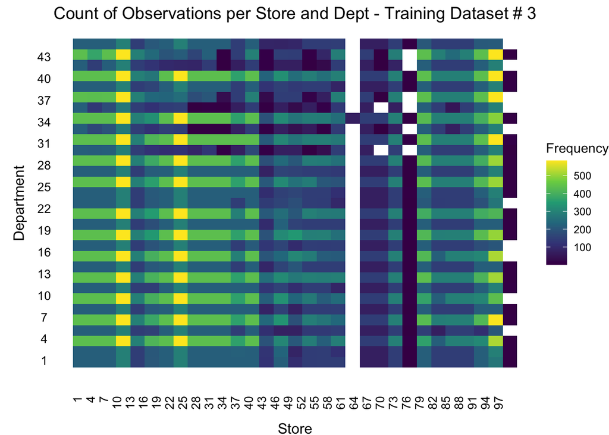

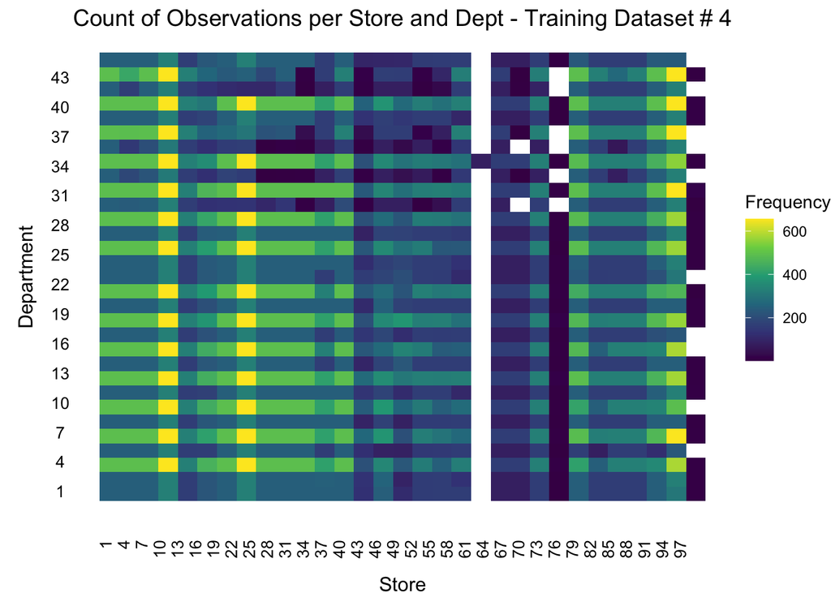

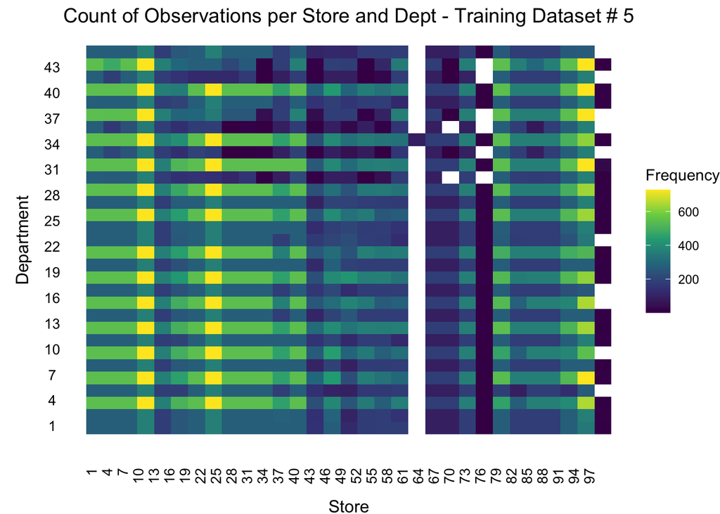

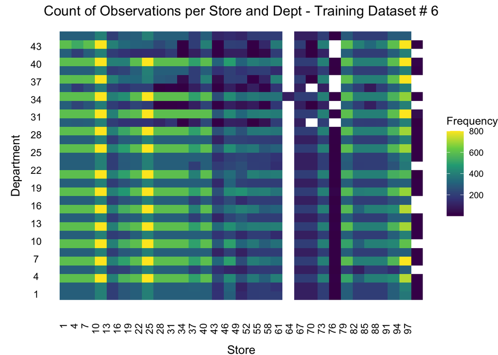

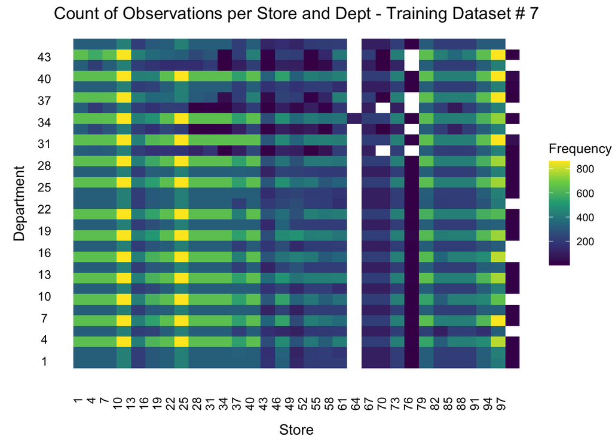

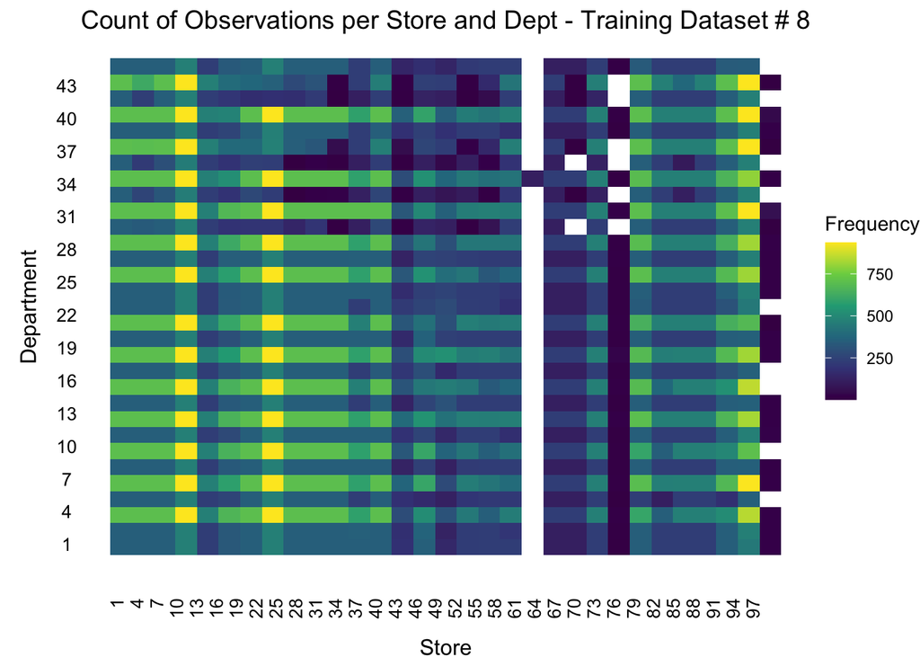

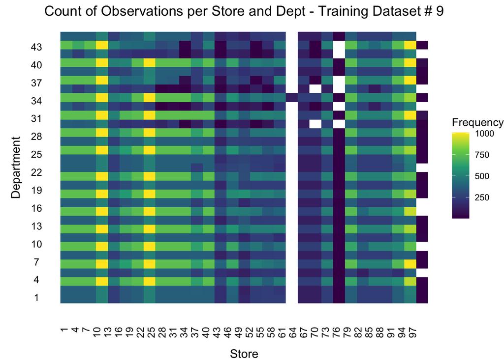

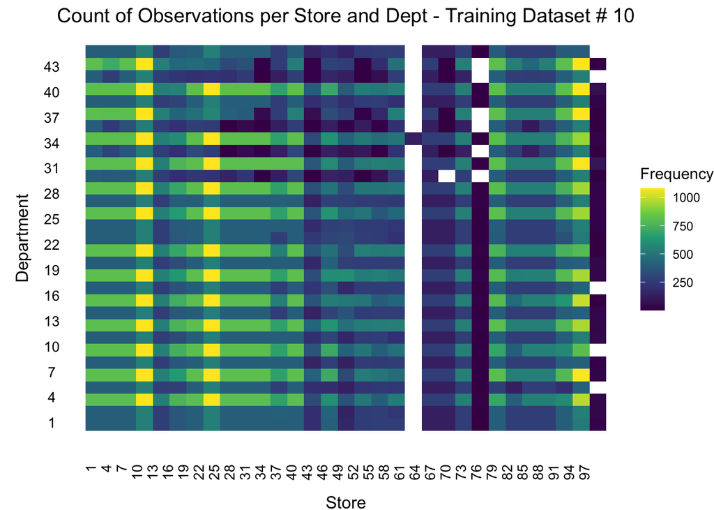

```r
for (fold in 1:10) {

  # Get the training and testing data per fold
  train <- get(paste0("train_", fold))

  # Create a dynamic title based on the fold number
  title <- paste("Count of Observations per Store and Dept - Training Dataset #", fold)

  # Create a heatmap
  g <- ggplot(train, aes(x = Dept, y = Store)) +
    geom_bin2d() +
    scale_x_continuous(breaks = seq(min(train$Dept), max(train$Dept), by = 3)) +
    scale_y_continuous(breaks = seq(min(train$Store), max(train$Store), by = 3)) +
    scale_fill_viridis_c(direction = 1) +
    labs(x = "Store", y = "Department", fill = "Frequency", title = title) +
    theme_void() +
    theme(
      axis.text.x = element_text(angle = 90, hjust = 1,  margin = margin(t = 10, r = 0, b = 10, l = 0)),
      axis.text = element_text(size = 10),
      axis.title.y = element_text(angle = 90, size = 12, margin = margin(t = 0, r = 10, b = 0, l = 10)),
      axis.title = element_text(size = 12),
      plot.title = element_text(size = 14, hjust = 0.5)
    )

  # Add the plot to the list
  print(g)
}
```

## **Part II: Training and testing Data**

The test data is stored in the same folds as the training data, with one test.csv in each fold. These can be loaded in a similar way as the trainig data was loaded:

```r
for (fold in 1:10) {

  # Construct the path to the files for this fold
  fold_folder <- file.path("./Proj2_Data", paste0("fold_", fold))

  # Read the training data
  test_path <- file.path(fold_folder, "test.csv")
  assign(paste0("test_", fold), read.csv(test_path, header = TRUE))

}
```

The test datasets contain the same variables as the training datasets, except for the `Weekly_Sales` variable. This will be the response variable in further analyses. These look like this:

```r
head(test_7)
```

```
##   Store Dept       Date IsHoliday
## 1     1    1 2012-03-02     FALSE
## 2     1    1 2012-03-09     FALSE
## 3     1    1 2012-03-16     FALSE
## 4     1    1 2012-03-23     FALSE
## 5     1    1 2012-03-30     FALSE
## 6     1    1 2012-04-06     FALSE
```

```r
max(train_1$Date)
```

```
## [1] "2011-02-25"
```

```r
unique(test_1$Date)
```

```
## [1] "2011-03-04" "2011-03-11" "2011-03-18" "2011-03-25" "2011-04-01"
## [6] "2011-04-08" "2011-04-15" "2011-04-22" "2011-04-29"
```

```r
date(max(train_1$Date))+7
```

```
## [1] "2011-03-04"
```

### 2.2. Labeled Test data

Conveniently, a dataset that contains the correct labels for the observations in the test sets is available: test_with_label.csv, and it is loaded as follows:

```r
test_with_label = read.csv("Proj2_Data/test_with_label.csv")
```

This file contains the real values of `Weekly_Sales` for the dates included in the testing data time span, and has the same structure as the training and testing(plus the `Weekly_Sales` column). This information becomes very useful later on to test the predictions accuracy.

## Data processing

Since several approaches are explored for the predictive analysis described in the following section, the details on data manipulation and transformations are discussed more in detail in every approach’s subsection.

## **Part III: Error Metric**

### 3.1. Error/Evaluation metric:

To test the accuracy of the predictions of this analysis, the metric used is weighted mean absolute error, `WMAE`. An implementation of a function that calculates this is error presented below:

```r
myeval = function(predict.name, test_with_label = test_with_label, num_folds){

  wmae = rep(0, num_folds)

  for (i in 1:num_folds) {

    # Use already loaded test data frame
    test = get(paste0("test_", i))
    test =  test %>%
      select(-IsHoliday) %>%
      left_join(test_with_label, by = c('Date', 'Store', 'Dept'))

    # Use already loaded predictions data frame
    test_pred = get(paste0(predict.name, i))

    new_test <- test %>%
      left_join(test_pred, by = c('Date', 'Store', 'Dept'))

    actuals = new_test$Weekly_Sales
    preds = new_test$Weekly_Pred
    weights = if_else(new_test$IsHoliday.x, 5, 1)
    weighted.sum = weights * abs(actuals - preds)

    weighted.sum[is.na(weighted.sum)] <- 0
    wmae[i] = sum(weighted.sum) / sum(weights)
  }
  return(list(wmae = wmae, mean.wmae = mean(wmae)))
}
```

This function:

- Takes as **input** the name of the test with predictions set `predict.name`, the target dataset `test_with_label` that defaults to “test_with_label” (purposely, the previously loaded dataframe that contains the real labels), and the number of folds `num_folds`.
- Calculates as **output** the `wmae` per fold and the `mean.wmae` of all the folds.

## **Part IV: Predictive Analysis**

### 4.1. A simplistic approach

```r
for (fold in 1:10) {

  # Get the the training and testing data per fold
  train <- get(paste0("train_", fold))
  test  <- get(paste0("test_", fold))


  ##### Simplistic Strategy: #####
  # Assigning the latest weekly sales to every combination of store and department as the prediction.
  most_recent_date <- max(train$Date)

  tmp_train <- train %>%
    filter(Date == most_recent_date) %>%
    dplyr::rename(Weekly_Pred = Weekly_Sales) %>%
    select(-Date, -IsHoliday)

  test_pred <- test %>%
    left_join(tmp_train, by = c('Dept', 'Store'))


  # assign zero to missing predictions
  id = is.na(test_pred$Weekly_Pred)
  test_pred$Weekly_Pred[id] = 0

  assign(paste0("simplistic.pred_", fold), test_pred)
}
```

The structure of the resulting predictions looks as follows:

```r
head(simplistic.pred_1)
```

```
##   Store Dept       Date IsHoliday Weekly_Pred
## 1     1    1 2011-03-04     FALSE    19363.83
## 2     1    1 2011-03-11     FALSE    19363.83
## 3     1    1 2011-03-18     FALSE    19363.83
## 4     1    1 2011-03-25     FALSE    19363.83
## 5     1    1 2011-04-01     FALSE    19363.83
## 6     1    1 2011-04-08     FALSE    19363.83
```

The accuracy of these results can be evaluated using the previously implemented error function:

```r
myeval(predict.name="simplistic.pred_", test_with_label, num_folds=10)
```

```
## $wmae
##  [1] 2078.726 2589.338 2253.936 2823.098 5156.012 4218.348 2269.904 2143.839
##  [9] 2221.145 2372.425
##
## $mean.wmae
## [1] 2812.677
```

Since this is a simplistic way of “predicting” future sales, more complicated methodologies are likely to give better results.

### 4.2. Linear Regression Models

An interesting idea could be using the information of the data to fit a regression model. For instance, temporal information in the variables `Yr` and `Date`: predict using the sales of a corresponding `week`: a numerical representation of each week of the year, ranging from 1 to 52 (or occasionally 53) (achieved by using the week function from the lubridate package) of the previous year being predicted. This is, for example, when predicting sales for Week 20 of 2011, use the data from Week 20 of 2010.

```r
length(unique(train_10$Store)) * length(unique(train_10$Dept))*10 # multiplied by 10 to account for the 10 folds
```

```
## [1] 36450
```

, a task that would likely be computationally very expensive. It is imperative to do this process in an time-economic way. The main idea behind the implementation is that not all departments/stores need a prediction. Departments not listed in the test sets and stores without data can be skipped. Such efficient implementation is presented below:

```r
# Progress
pb <- progress_bar$new(total = 10, format = "[:bar] [:percent] [Elapsed time: :elapsedfull] [ETA: :eta]", force = TRUE)

for (fold in 1:10) {

  # Get the training and testing data per fold
  train <- get(paste0("train_", fold))
  test  <- get(paste0("test_", fold))


  # find the unique pairs of (Store, Dept) combo that appeared in both training and test sets
  train_pairs <- train[, 1:2] %>% count(Store, Dept) %>% filter(n != 0)
  test_pairs <- test[, 1:2] %>% count(Store, Dept) %>% filter(n != 0)
  unique_pairs <- intersect(train_pairs[, 1:2], test_pairs[, 1:2])

  # pick out the needed training samples, convert to dummy coding, then put them into a list
  train_split <- unique_pairs %>%
    left_join(train, by = c('Store', 'Dept')) %>%
    mutate(Wk = factor(ifelse(year(Date) == 2010, week(Date) - 1, week(Date)), levels = 1:52)) %>%
    mutate(Yr = year(Date))

  test_split <- unique_pairs %>%
    left_join(test, by = c('Store', 'Dept')) %>%
    mutate(Wk = factor(ifelse(year(Date) == 2010, week(Date) - 1, week(Date)), levels = 1:52)) %>%
    mutate(Yr = year(Date))

  # construct the design matrix only once
  train_split = as_tibble(model.matrix(~ Weekly_Sales + Store + Dept + Yr + Wk, train_split)) %>%
    group_split(Store, Dept)
  test_split = as_tibble(model.matrix(~ Store + Dept + Yr + Wk, test_split)) %>%
    mutate(Date = test_split$Date) %>%
    group_split(Store, Dept)

  # pre-allocate a list to store the predictions
  test_pred <- vector(mode = "list", length = nrow(unique_pairs))


  # perform regression for each split, note we used lm.fit instead of lm
  for (i in 1:nrow(unique_pairs)) {

    # Training Data
    tmp_train <- train_split[[i]]

    x.train <- as.matrix(tmp_train[, -(2:4)])
    x.train <- as.matrix(   cbind(x.train[,c(1:2),  drop = FALSE],
                                  "Yr2" = (x.train[,c(2),  drop = FALSE])^2,
                                  x.train[,-c(1, 2), drop = FALSE])   )  # adds year^2 column as the second column of the matrix

    y.train <- tmp_train$Weekly_Sales


    # Testing Data
    tmp_test <- test_split[[i]]

    x.test <- as.matrix(tmp_test[, 4:55])
    x.test <- as.matrix( cbind("Yr" = x.test[,c(1),  drop = FALSE],
                               "Yr2" = (x.test[,c(1),  drop = FALSE])^2,
                               x.test[,-c(1), drop = FALSE])) # adds year^2 column as the second column of the matrix


    # Model
    mycoef <- lm.fit(x.train, y.train)$coefficients
    mycoef[is.na(mycoef)] <- 0

    # Prediction
    tmp_pred <- mycoef[1] + x.test %*% mycoef[-1]
    tmp_pred[is.na(tmp_pred)] <- 0



    tmp_pred.df <- data.frame( Store = unique(tmp_test$Store),
                               Dept = unique(tmp_test$Dept),
                               Date = tmp_test$Date,
                               IsHoliday = test[test$Store == unique(tmp_test$Store) & test$Dept == unique(tmp_test$Dept),]$IsHoliday,
                               Weekly_Pred = tmp_pred)

      test_pred[[i]] <- tmp_pred.df
    }

   # This combines the results of all the linear models as dataframes already into a big dataframe for the fold.
   assign(paste0("test.pred_", fold), bind_rows(test_pred))

   # Update the progress bar
   pb$tick()
}
```

```
##
[======>--------------------------] [ 20%] [Elapsed time: 00:00:15] [ETA:
## 1m]
[=========>-----------------------] [ 30%] [Elapsed time: 00:00:32] [ETA:
## 1m]
[============>--------------------] [ 40%] [Elapsed time: 00:00:51] [ETA:
## 1m]
[===============>-----------------] [ 50%] [Elapsed time: 00:01:11] [ETA:
## 1m]
[===================>-------------] [ 60%] [Elapsed time: 00:01:32] [ETA:
## 1m]
[======================>----------] [ 70%] [Elapsed time: 00:01:55] [ETA:
## 49s]
[=========================>-------] [ 80%] [Elapsed time: 00:02:18] [ETA:
## 35s]
[=============================>---] [ 90%] [Elapsed time: 00:02:43] [ETA:
## 18s]
[=================================] [100%] [Elapsed time: 00:03:09] [ETA:
## 0s]
```

Just like before, the accuracy can be evaluated using the implemented WMAE function:

```r
myeval(predict.name="test.pred_", test_with_label, num_folds=10)
```

```
## $wmae
##  [1] 2045.088 1466.872 1449.774 1593.858 2321.792 1677.478 1646.047 1365.176
##  [9] 1358.769 1345.174
##
## $mean.wmae
## [1] 1627.003
```

### 4.3. Linear Regression Models on smooth data

### **SVD - Smoothed data**

Starting from recommendations from previous works on this data (Prof. Feng Liang), and through trial and error, it was determined that the performance of the predictive models improved significantly when working with a ‘smoothed/denoised version’ of the training data. To achieve this, Singular Value Decomposition (SVD) was performed using the `svd()` function, included in the base R. The idea behind this is that that the dominant shared Principal Components (PCs) likely represent meaningful signals, whereas PCs with minimal variances are mostly noise. Thus, the original “noisy” dataset ${X}$ is set aside, and the predictive analysis is performed with the de-noised dataset $\tilde{X}$. In this analysis, the number of PCs kept is set to `d=8`.

```r
# Progress
pb <- progress_bar$new(total = 10, format = "[:bar] [:percent] [Elapsed time: :elapsedfull] [ETA: :eta]", force = TRUE)

for (fold in 1:10) {

  # Get the training and testing data per fold
  train <- get(paste0("train_", fold))
  train_smoothed <- data.frame()
  d <- 8  # Specify the number of components to keep

  existing.dept = unique(train$Dept)

  for (department in existing.dept) {

    train_dep <- train[ which(train$Dept== department ), ]

    if (length(unique(train_dep$Store))<2) {
      data_frame <- data.frame(Store = train_dep$Store, Dept=train_dep$Dept, Date=train_dep$Date, Weekly_Sales = train_dep$Weekly_Sales)
    }

    else{
    train_temp2 <- train_dep %>%
      select(Store, Date, Weekly_Sales) %>%
      spread(Store, Weekly_Sales)
    train_temp2[is.na(train_temp2)] <- 0

    train_temp3 <-  t(train_temp2[, -1])

    # To center the dataset
    store.mean <- rowMeans(train_temp3)
    train_temp4 <- (train_temp3)-store.mean

    # SVD
    svd_result <- svd(train_temp4)
    U <- svd_result$u
    D <- diag(svd_result$d)
    V <- svd_result$v

    min.com = ncol(U)
    X_reduced_temp <- (U[,1:min(min.com,d)] %*% D[1:min(min.com,d),1:min(min.com,d)] %*% t(V[,1:min(min.com,d)]))
    X_reduced <- X_reduced_temp + matrix(rep(store.mean, times = dim(X_reduced_temp)[2]), nrow = length(store.mean), ncol = dim(X_reduced_temp)[2])

    X_reduced_df<- as.data.frame(t(X_reduced))
    names(X_reduced_df) <- names(train_temp2)[-1]
    X_reduced_df$Date <- train_temp2$Date
    data_frame_temp <- gather(X_reduced_df, key = "Store", value = "Weekly_Sales", -Date)
    data_frame_temp$Dept <-rep(department, times  = dim(data_frame_temp)[1])
    desired_order <- c("Store", "Dept", "Date","Weekly_Sales")
    data_frame_temp <- data_frame_temp[, desired_order]
    data_frame_temp$Store<- as.numeric(data_frame_temp$Store)
    }

    train_smoothed <- rbind(train_smoothed, data_frame_temp)
  }

    assign(paste0("train.smooth_", fold), train_smoothed)

   # Update the progress bar
   pb$tick()
}
```

```
##
[======>--------------------------] [ 20%] [Elapsed time: 00:00:01] [ETA:
## 7s]
[=========>-----------------------] [ 30%] [Elapsed time: 00:00:03] [ETA:
## 9s]
[============>--------------------] [ 40%] [Elapsed time: 00:00:05] [ETA:
## 9s]
[===============>-----------------] [ 50%] [Elapsed time: 00:00:08] [ETA:
## 8s]
[===================>-------------] [ 60%] [Elapsed time: 00:00:10] [ETA:
## 7s]
[======================>----------] [ 70%] [Elapsed time: 00:00:13] [ETA:
## 6s]
[=========================>-------] [ 80%] [Elapsed time: 00:00:16] [ETA:
## 4s]
[=============================>---] [ 90%] [Elapsed time: 00:00:19] [ETA:
## 2s]
[=================================] [100%] [Elapsed time: 00:00:22] [ETA:
## 0s]
```

The resulting reconstructed and denoised `train.smooth` dataframes hold the same structure as the original training data:

```r
head(train.smooth_7)
```

```
##   Store Dept       Date Weekly_Sales
## 1     1    1 2010-02-05     25385.79
## 2     1    1 2010-02-12     46887.33
## 3     1    1 2010-02-19     38562.33
## 4     1    1 2010-02-26     20160.12
## 5     1    1 2010-03-05     21865.19
## 6     1    1 2010-03-12     21068.78
```

Now, for this predictive modeling, the training and testing data undergo the same transformations required for the previous approach (4.2.):

1. For each `store` and each `department` within that store, a list of the unique pairs of departments and stores that are present in both the training and testing set is built.
2. Using functions from the `lubridate` library, a new variable **`Wk`**(week) replaces the `Date` variable. This makes working with the dates easier and more systematic.

For each unique pair of **`store`** and **`department`**, using the variables **`Yr`** and its square **`Yr^2`** as a numerical predictor and `Wk` as a categorical predictor, a linear regression model characterized as: `Y ~ Yr + Yr^2 + Wk` is fitted using the `lm.fit()` function. With such models, the predictions are made for the corresponding ‘test’ dataset.

The following code loops through all the folds, handles the described transformations, fits a multiple linear regression model to predict the `Weekly_Sales` for the weeks of the testing datasets, and stores the predictions in a *test.pred.smooth_i* dataframe:

```r
# Progress
pb <- progress_bar$new(total = 10, format = "[:bar] [:percent] [Elapsed time: :elapsedfull] [ETA: :eta]", force = TRUE)

for (fold in 1:10) {

  # Get the training and testing data per fold
  train <- get(paste0("train.smooth_", fold))
  test <- get(paste0("test_", fold))


  # find the unique pairs of (Store, Dept) combo that appeared in both training and test sets
  train_pairs <- train[, 1:2] %>% count(Store, Dept) %>% filter(n != 0)
  test_pairs <- test[, 1:2] %>% count(Store, Dept) %>% filter(n != 0)
  unique_pairs <- intersect(train_pairs[, 1:2], test_pairs[, 1:2])


  # pick out the needed training samples, convert to dummy coding, then put them into a list
  train_split <- unique_pairs %>%
    left_join(train, by = c('Store', 'Dept')) %>%
    mutate(Wk = factor(ifelse(year(Date) == 2010, week(Date) - 1, week(Date)), levels = 1:52)) %>%
    mutate(Yr = year(Date))

  test_split <- unique_pairs %>%
    left_join(test, by = c('Store', 'Dept')) %>%
    mutate(Wk = factor(ifelse(year(Date) == 2010, week(Date) - 1, week(Date)), levels = 1:52)) %>%
    mutate(Yr = year(Date))


  # construct the design matrix only once
  train_split = as_tibble(model.matrix(~ Weekly_Sales + Store + Dept + Yr + Wk, train_split)) %>%
    group_split(Store, Dept)

  test_split = as_tibble(model.matrix(~ Store + Dept + Yr + Wk, test_split)) %>%
    mutate(Date = test_split$Date) %>%
    group_split(Store, Dept)

  # pre-allocate a list to store the predictions
  test_pred <- vector(mode = "list", length = nrow(unique_pairs))




  # Perform regression for each split, note we used lm.fit instead of lm
  for (i in 1:nrow(unique_pairs)) {

    # Training Data
    tmp_train <- train_split[[i]]

    x.train <- as.matrix(tmp_train[, -(2:4)])
    x.train <- as.matrix(   cbind(x.train[,c(1:2),  drop = FALSE],"Yr2" = (x.train[,c(2),  drop = FALSE])^2, x.train[,-c(1, 2), drop = FALSE])   )  # adds year^2 column as the second column of the matrix

    y.train <- tmp_train$Weekly_Sales

    # Testing Data
    tmp_test <- test_split[[i]]

    x.test <- as.matrix(tmp_test[, 4:55])
    x.test <- as.matrix( cbind("Yr" = x.test[,c(1),  drop = FALSE],"Yr2" = (x.test[,c(1),  drop = FALSE])^2, x.test[,-c(1), drop = FALSE])) # adds year^2 column as the second column of the matrix



    # Model
    mycoef <- lm.fit(x.train, y.train)$coefficients

    mycoef[is.na(mycoef)] <- 0
    tmp_pred <- mycoef[1] + x.test %*% mycoef[-1]
    tmp_pred[is.na(tmp_pred)] <- 0

    tmp_pred.df <- data.frame(
      Store = unique(tmp_test$Store),
      Dept = unique(tmp_test$Dept),
      Date = tmp_test$Date,
      IsHoliday = test[test$Store == unique(tmp_test$Store) & test$Dept == unique(tmp_test$Dept),]$IsHoliday,
      Weekly_Pred = tmp_pred)

      test_pred[[i]] <- tmp_pred.df
    }

   # This combines the results of all the linear models as dataframes already into a big dataframe for the fold.
   assign(paste0("test.pred.smooth_", fold), bind_rows(test_pred))

   # Update the progress bar
   pb$tick()
}
```

```
##
[======>--------------------------] [ 20%] [Elapsed time: 00:00:16] [ETA:
## 1m]
[=========>-----------------------] [ 30%] [Elapsed time: 00:00:37] [ETA:
## 1m]
[============>--------------------] [ 40%] [Elapsed time: 00:00:56] [ETA:
## 1m]
[===============>-----------------] [ 50%] [Elapsed time: 00:01:17] [ETA:
## 1m]
[===================>-------------] [ 60%] [Elapsed time: 00:01:38] [ETA:
## 1m]
[======================>----------] [ 70%] [Elapsed time: 00:02:01] [ETA:
## 1m]
[=========================>-------] [ 80%] [Elapsed time: 00:02:26] [ETA:
## 37s]
[=============================>---] [ 90%] [Elapsed time: 00:02:49] [ETA:
## 19s]
[=================================] [100%] [Elapsed time: 00:03:14] [ETA:
## 0s]
```

The accuracy of the predictions obtained through the used methodology can be evaluated using the WMAE function implemented earlier:

```r
myeval(predict.name="test.pred.smooth_", test_with_label, num_folds=10)
```

```
## $wmae
##  [1] 1938.903 1360.881 1377.585 1523.277 2304.853 1632.857 1611.032 1353.578
##  [9] 1334.890 1330.739
##
## $mean.wmae
## [1] 1576.86
```

This approach takes pretty much the same amount of time as *4.2.* to perform the analyses and yields an improved performance. Such improvements lead to comparable results to the benchmark discussed in the Kaggle competition where this data was obtained from.

#### Results Visualization

The predicted sales can be visualized against the real values for each fold and the time span that fold corresponds to:

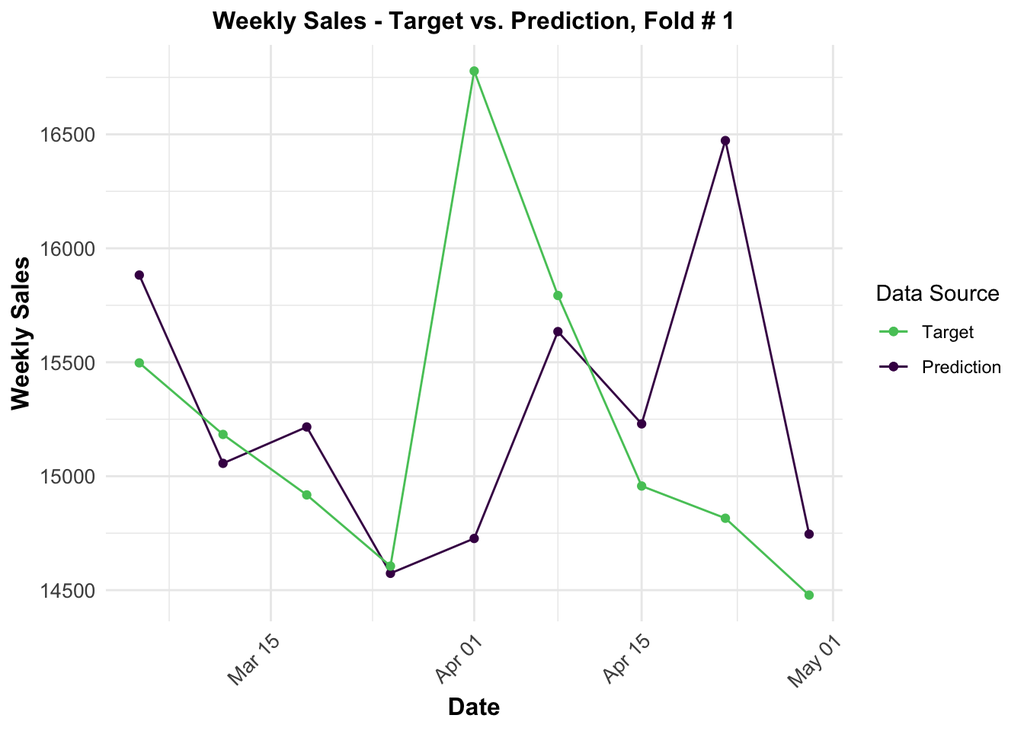

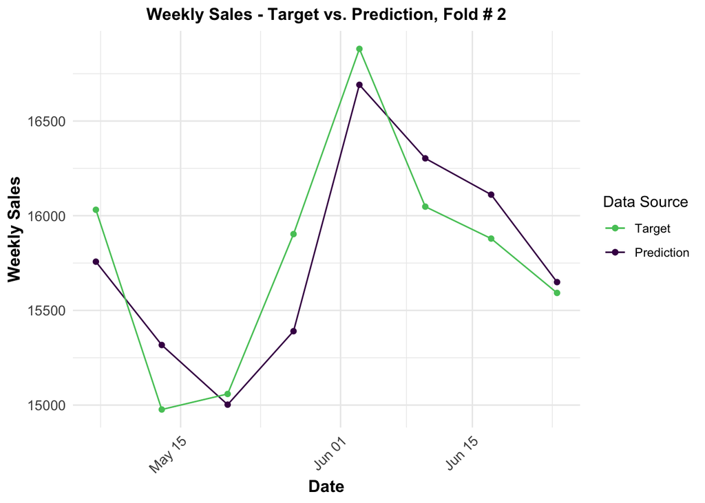

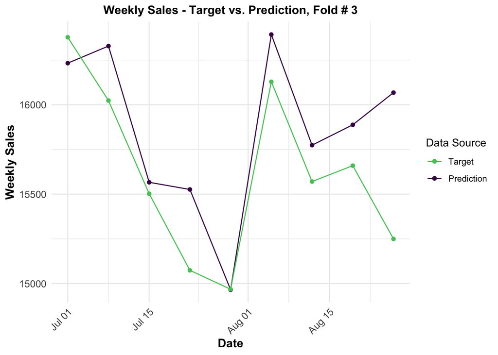

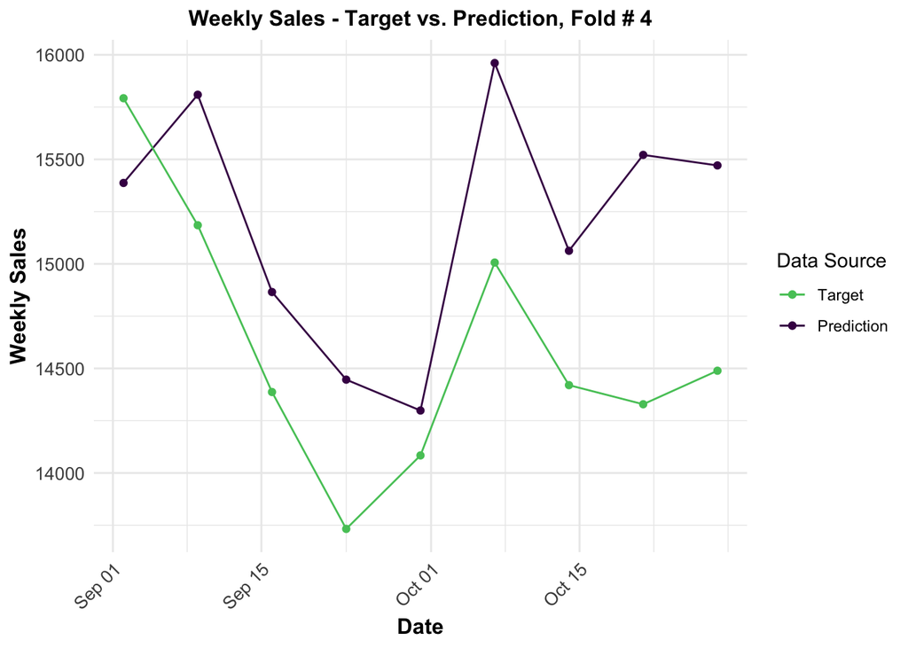

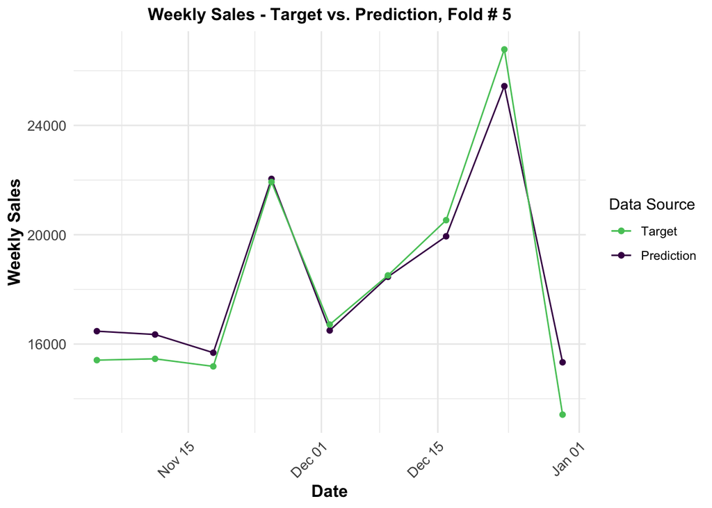

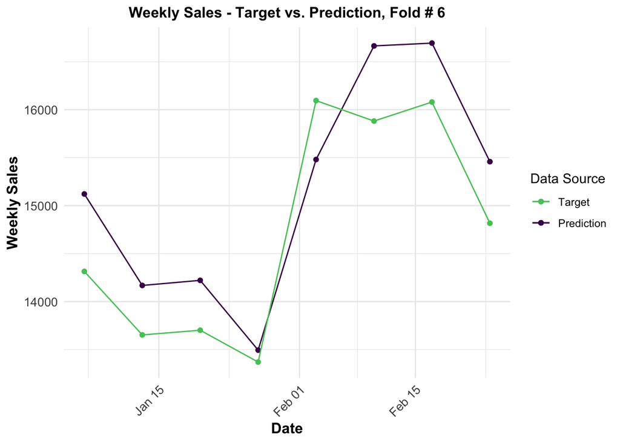

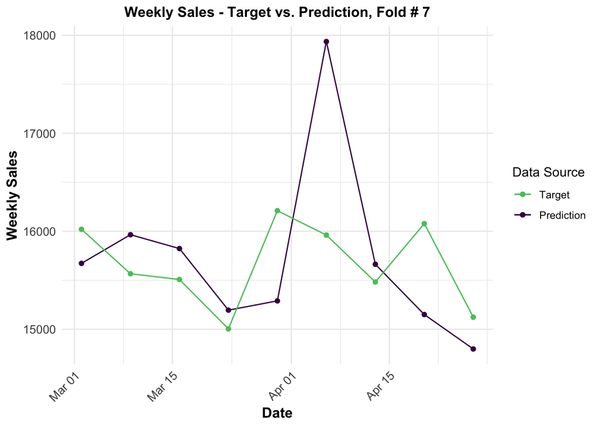

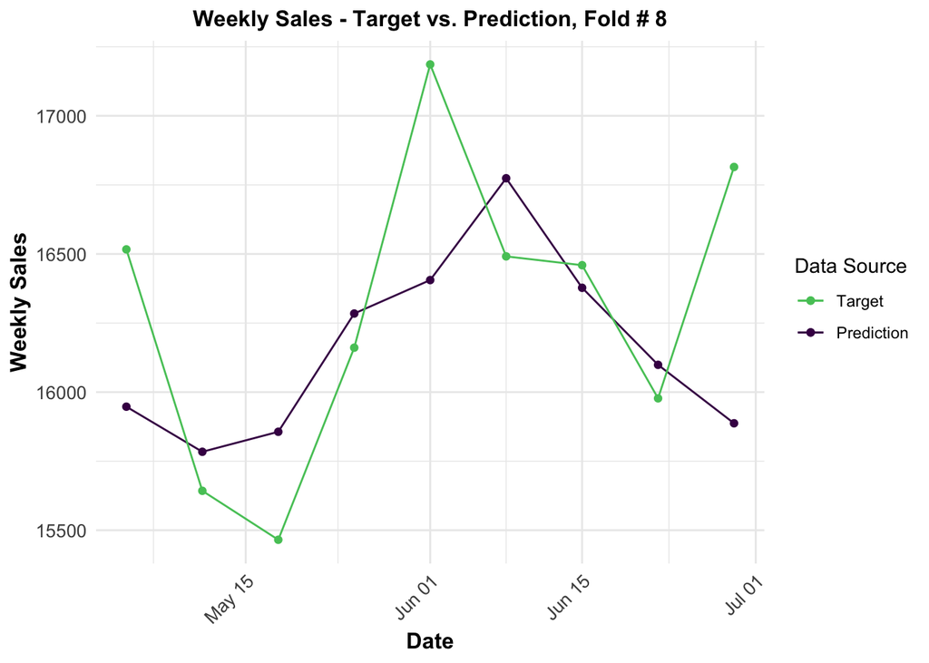

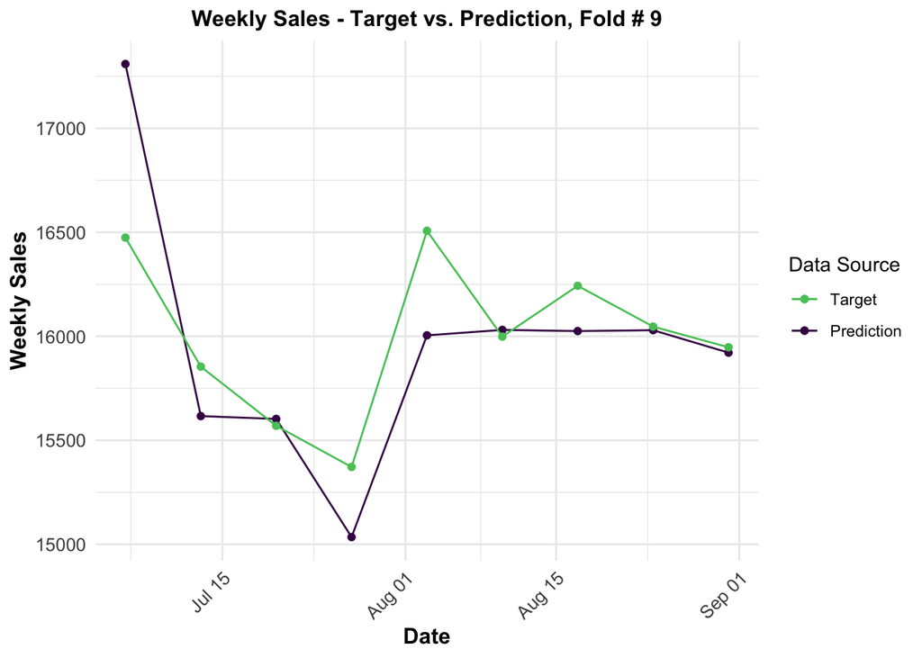

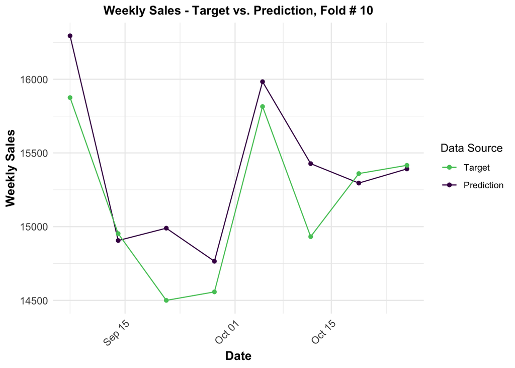

```r
for (fold in 1:10) {
    # Get the training and testing data per fold
    target <- get(paste0("test_", fold))
    test.pred  <- get(paste0("test.pred.smooth_", fold))

    #Target/labels
    target_ = target %>%
          select(-IsHoliday) %>%
          left_join(test_with_label, by = c('Date', 'Store', 'Dept'))

    target_ = target_ %>%
      group_by(Date) %>%  # Group by week
      summarize(Target = mean(Weekly_Sales))

    #Predictions
    predct_ = test.pred %>%
      group_by(Date) %>%  # Group by week
      summarize(Prediction = mean(Weekly_Pred))


    # Combine the 'target_' and 'predct_' datasets into one
    test.vs.pred <- cbind(
      "Date" = target_$Date,
      "Target" = target_[,2, drop = FALSE],
      "Prediction" = predct_[,2, drop = FALSE])


    # Dynamic title based on the fold number
  title <- paste("Weekly Sales - Target vs. Prediction, Fold #", fold)

  p <- ggplot(test.vs.pred, aes(x = as.Date(Date))) +
      geom_line(aes(y = Target, color = "Target"), linetype = "solid") +
      geom_point(aes(y = Target, color = "Target")) +

      geom_line(aes(y = Prediction, color = "Prediction"), linetype = "solid") +
      geom_point(aes(y = Prediction, color = "Prediction")) +

      scale_color_manual(
        values = c("Target" = "#440154FF", "Prediction" = "#55C667FF"),
        labels = c("Target", "Prediction")
      ) +
      labs(
        x = "Date",
        y = "Weekly Sales",
        title = title,
        color = "Data Source"  # This will be the title of the legend for color
      ) +
      theme_minimal() +
      theme(
        axis.text.x = element_text(angle = 45, hjust = 1),
        axis.text = element_text(size = 10),
        axis.title = element_text(size = 12, face = "bold"),
        plot.title = element_text(size = 12, face = "bold", hjust = 0.5)
      )


    print(p)
}
```

#### 4.4. Other approaches explored

During this project, several other methodologies where implemented. Among these, some ideas regarded:

1. More complex predictive models, like random forests and other non-linear statistical models.
2. Including other variables as predictors: `IsHoliday`, as a categorical variable.
3. Trying to build upon the linear regression model and making it robust to “outliers” by using an L1-norm optimization (as oposed to the classical L2-norm approach):

```r
  my.L1 <- function(params) {
    # params is a vector

    # ** y_hat * x **
    y_hat = params[1] + x.train[,-1] %*% params[-1]

    # ** r **
    res = y_hat - y.train

    # ** L1 Norm **
    return(norm(res, type = "1"))
  }

# &&

##### Robust Regression with L1 norm
  ## L2 coeffs used as a starting point. Updated with:
  mycoef <- optim(mycoef, my.L1)$par
```

These approaches came at a significant computational price (specially a. and c., given the nature of the data and the models, and the optimization steps), but no significant improvements were found. A more extensive, in-depth analysis may result in interesting findings on these approahces (or any other relevant techniques, for that matter) for this problem.

Notes:

The total runtime of this R code is:

```r
end.time <- Sys.time()
total.runtime <- end.time - start.time
total.runtime
```

```
## Time difference of 7.609353 mins
```

The presented code/R markdown document builds up from the material from and work done for the course STAT 542: Statistical Learning.